# Theory Driven Text Analysis Workshop

Text Pre-processing SPSP 2020

Joe Hoover & Brendan Kennedy

joseph.hoover@kellogg.northwestern.edu

btkenned@usc.edu

# Workshop Data

Throughout this workshop, we will be working with a collection of United States Congressional speeches from the House. This data is stored in JSONL format.

It is stored in the file: `../data/tdta_house_data.json`

# Loading data

Text data can be stored in many formats:

- CSV
- Separate files (e.g. txt) for each “document”
- A single txt with documents newline delimited
- JSON
- JSONL/NDJSON
- XML
- …

With this much variation, the first challenge of text analysis is often figuring out how to load your data! Sometimes you know the format a priori, which simplifies the task. However, other times you might not know the format. In those instances, it’s useful to take a glance at the raw data.

We can do that with the `readLines` function:

```r
readLines('../data/tdta_house_data.json', n=1)
```

```
[1] "{\"speaker\":\"Mr. GEKAS.\",\"segment\":\" Mr. Speaker, earlier today, October 7, 1998, I was \\nunavoidably detained while discussing the conference committee report \\non bankruptcy reform and missed a recorded vote on <a href=\\\"/bill/105th-congress/house-bill/4570\\\">H.R. 4570<\\/a>, the …
```

**Question:** Any idea what format this data is?

## JSON formatted data

### JSON

JSON is a data storage format that is widely used for storing text data. It has the following characteristics:

- Data is in name/value pairs
- Data is separated by commas
- Curly braces (“{” and “}”) hold objects

For example,

```r
# JSON eg 1
{'name': 'joe',
 'city': 'chicago'
}
#JSON eg 2
{'name': c('joe', 'brendan'),
 'city': c('chicago', 'los angeles')
}
```

### JSONL/NDJSON

Often, a collection of data or a corpus of text is stored in multiple JSON objects that are delimited by a newline. For intsance, a corpus of 100 documents might be stored in a file with 100 json objects, one for each document, delimited by a new line. Data with this format is usually referred to as JSONL (e.g. JSON lines) or NDJSON (e.g. new line delimited JSON).

For example, a file containing the json objects below would be a JSONL format data object:

```r
# JSON eg 1
{'name': 'joe', 'city': 'chicago', 'text': 'Hi'}
{'name': 'brendan', 'city': 'los angeles', 'text': 'Howdy'}
```

## Loading Workshop Data

Our data has a JSONL format. To load it, we will use the `stream_in` function from the `jsonlite` package. Specifically, we’ll provide a file connection to our data file as the first argument to `stream_in`.

The `stream_in` function will read the JSONL file and store it in an R data.frame object.

```r
dh <- stream_in(file("../data/tdta_house_data.json"))
```

# Processing Workshop Data

First, let’s try to get an idea of how the data is structured.

```r
str(dh)
```

```
'data.frame':   35959 obs. of  10 variables:
 $ speaker : chr  "Mr. GEKAS." "Mr. VENTO." "Mr. LaFALCE." "Mr. VENTO." ...
 $ segment : chr  " Mr. Speaker, earlier today, October 7, 1998, I was \nunavoidably detained while discussing the conference comm"| __truncated__ " Mr. Speaker, I have taken this hour special order this \nevening to highlight an important law and an importan"| __truncated__ " Mr. Speaker, I thank t…
 $ url     : chr  "https://www.congress.gov//congressional-record/1998/10/07/house-section/article/H9870-1" "https://www.congress.gov//congressional-record/1999/06/23/house-section/article/H4815-1" "https://www.congress.gov//congressional-record/1999/06/23/house-section/article/H4815-1" "https://www…
 $ session : chr  "<h4>105th Congress, 2nd Session<br/>Issue: Vol. 144, No. 139 — Daily Edition</h4>" "<h4>106th Congress, 1st Session<br/>Issue: Vol. 145, No. 90 — Daily Edition</h4>" "<h4>106th Congress, 1st Session<br/>Issue: Vol. 145, No. 90 — Daily Edition</h4>" "<h4>106th Congress, 1st Session…
 $ doc_num : int  273 652 653 654 655 656 657 658 659 660 ...
 $ State   : chr  "Connecticut" "New York" "Idaho" "New York" ...
 $ Party   : chr  "Democratic" "Democratic" "Republican" "Democratic" ...
 $ Name    : chr  "Gekas, George W." "Vento, Bruce F." "LaFalce, John J." "Vento, Bruce F." ...
 $ District: chr  "District: 2" "District: 7" "District: 1" "District: 7" ...
 $ date    : num  9.08e+11 9.30e+11 9.30e+11 9.30e+11 9.30e+11 ...
```

```r
summary(dh)
```

```
   speaker            segment              url              session
 Length:35959       Length:35959       Length:35959       Length:35959
 Class :character   Class :character   Class :character   Class :character
 Mode  :character   Mode  :character   Mode  :character   Mode  :character



    doc_num          State              Party               Name
 Min.   :   273   Length:35959       Length:35959       Length:35959
 1st Qu.:185630   Class :character   Class :character   Class :character
 Median :361623   Mode  :character   Mode  :character   Mode  :character
 Mean   :381072
 3rd Qu.:587280
 Max.   :787459
   District              date
 Length:35959       Min.   :8.968e+11
 Class :character   1st Qu.:9.017e+11
 Mode  :character   Median :9.082e+11
                    Mean   :9.130e+11
                    3rd Qu.:9.253e+11
                    Max.   :9.308e+11
```

```r
cat(paste('Speaker: ', dh$speaker[1], '\n\nSegment: ', dh$segment[1], sep=''))
```

```
Speaker: Mr. GEKAS.

Segment:  Mr. Speaker, earlier today, October 7, 1998, I was
unavoidably detained while discussing the conference committee report
on bankruptcy reform and missed a recorded vote on <a href="/bill/105th-congress/house-bill/4570">H.R. 4570</a>, the
Omnibus National Parks and Public Lands Act of 1998. Had I been
present, I would have voted ``aye'' on rollcall No. 489, to agree to
<a href="/bill/105th-congress/house-bill/4570">H.R. 4570</a>.

                          ____________________
```

### Date Formatting

First, let’s deal with the date field:

```r
head(dh$date)
```

```
[1] 907718400000 930096000000 930096000000 930096000000 930096000000 930096000000
```

**Question:** What format is this data?

We can use the `as_date` function from the `lubridate` package to convert the UNIX timestamps to human-readable date objects:

```r
dhp <- dh %>%
  mutate(raw_date = date,
         date = lubridate::as_datetime(date))
head(dhp$date)
```

```
[1] "30734-06-15 UTC" "31443-07-28 UTC" "31443-07-28 UTC" "31443-07-28 UTC"
[5] "31443-07-28 UTC" "31443-07-28 UTC"
```

Wait…what’s going on here? Obviously this isn’t correct. What do we do?

Well, fortunately, each observation is associated with a URL. So, we can at least get check the correct date for the first record:

```r
dh$url[1]
```

```
[1] "https://www.congress.gov//congressional-record/1998/10/07/house-section/article/H9870-1"
```

“https://www.congress.gov//congressional-record/1998/10/07/house-section/article/H9870-1”

It looks like the correct date for the first is October 07, 1998. With that information, we can figure out what the timestamp *should* be (roughly):

```r
should_be = as.numeric(as.POSIXct("1998-10-07", format="%Y-%m-%d"))
is = dh$date[1]
cat(paste('Should be: ', should_be, ' (Digits = ', nchar(should_be),')\n',
          'Is: ', is, ' (Digits = ', nchar(is),')\n', sep=''))
```

```
Should be: 907736400 (Digits = 9)
Is: 907718400000 (Digits = 12)
```

It looks like we’re off by about three orders of magnitude. If we fix this, do we get the right date?

```r
as_datetime(is/1000)
```

```
[1] "1998-10-07 UTC"
```

Let’s try this for all the data and hand check a few cases:

```r
dhp <- dh %>%
  mutate(raw_date = date,
         date = lubridate::as_datetime(date/1000))
dhp %>% select(date, url) %>% head()
```

|  | date | url |
| --- | --- | --- |
| 1 | 1998-10-07 | https://www.congress.gov//congressional-record/1998/10/07/house-section/article/H9870-1 |
| 2 | 1999-06-23 | https://www.congress.gov//congressional-record/1999/06/23/house-section/article/H4815-1 |
| 3 | 1999-06-23 | https://www.congress.gov//congressional-record/1999/06/23/house-section/article/H4815-1 |
| 4 | 1999-06-23 | https://www.congress.gov//congressional-record/1999/06/23/house-section/article/H4815-1 |
| 5 | 1999-06-23 | https://www.congress.gov//congressional-record/1999/06/23/house-section/article/H4815-1 |
| 6 | 1999-06-23 | https://www.congress.gov//congressional-record/1999/06/23/house-section/article/H4815-1 |

## Text Pre-processing

### Regex

Next, we’ll start to clean up our text data, which is contained in the `segments` field. First, let’s look at a random document and see what we might need to clean:

```r
dhp$segment[100]
```

```
[1] " Mr. Speaker, I yield 2\\1/2\\ minutes to the gentleman \nfrom Pennsylvania (Mr. Peterson).\n  "
```

At least in this post, there are numbers, new line characters, `\n`, and some meaningless punctuation, e.g. ’'. To do this, we’ll use regex and the function `gsub` which uses regex pattern matching to find patterns and replace them with a specified set of characters.

```r
dhp <- dhp %>%
  mutate(text = gsub('\\\\|/', '', segment), # Remove '\' and '/'
         text = gsub('\\d+', 'NUM', text),
         text = gsub('\\\n|\\s+', ' ', str_trim(text)))
```

```r
dhp$text[100]
```

```
[1] "Mr. Speaker, I yield NUM minutes to the gentleman from Pennsylvania (Mr. Peterson)."
```

What else might we want to fix? Let’s look at the beginning of a few documents:

```r
substr(dhp$text[c(1:3, 400:403, 20000, 20002)], 0, 50)
```

```
[1] "Mr. Speaker, earlier today, October NUM, NUM, I wa"
[2] "Mr. Speaker, I have taken this hour special order "
[3] "Mr. Speaker, I thank the gentleman from Minnesota "
[4] "Mr. Chairman, we cannot get an answer to the quest"
[5] "Mr. Chairman, how much time do I have remaining? T"
[6] "Mr. Chairman, I yield NUM minute to the gentleman "
[7] "Mr. Chairman, I yield myself such time as I may co"
[8] "Mr. Speaker, I thank the distinguished chairman of"
[9] "I yield to the gentleman from New York."
```

**Problem:** How could we remove these strings from each document?

```r
# Add the correct regex patterns to remove 'Mr. Speaker,', 'Mr. Chairman,', 'Mrs. Speaker,' 'Mrs. Chairman,' and 'Madam Speaker,' 'Madam Chairman,'
dhp <- dhp %>%
  mutate(text = gsub('', '', text))
```

```r
# Add the correct regex patterns to remove 'Mr. Speaker,', 'Mr. Chairman,', 'Mrs. Speaker,' 'Mrs. Chairman,' and 'Madam Speaker,' 'Madam Chairman,'
suffix = c('Speaker,', 'Chairman,', 'Chairwoman,')
mr = paste('Mr.', suffix)
mrs = paste('Mrs.', suffix)
intro_strs = paste(c(mr, mrs), collapse='|')
dhp <- dhp %>%
  mutate(text = gsub(intro_strs, '', text),
         text =str_trim(text))
```

```r
substr(dhp$text[c(1:3, 400:403, 20000, 20002)], 0, 50)
```

```
[1] "earlier today, October NUM, NUM, I was unavoidably"
[2] "I have taken this hour special order this evening "
[3] "I thank the gentleman from Minnesota very much for"
[4] "we cannot get an answer to the question, and that "
[5] "how much time do I have remaining? The CHAIRMAN. T"
[6] "I yield NUM minute to the gentleman from Florida ("
[7] "I yield myself such time as I may consume. To the "
[8] "I thank the distinguished chairman of the Committe"
[9] "I yield to the gentleman from New York."
```

Finally, if you look long enough, you’ll notice quite a few HTML tags, like `<a href=\"billNUMth-congresshouse-billNUM\">`. Let’s go ahead and remove those:

```r
dhp <- dhp %>%
  mutate(text = gsub('<.*?>', '', text))
```

### `tidytext`

The notion of *tidy* data is quite popular among R users.

Generally, there are three rules for tidy data:

1. Each variable must have its own column.
2. Each observation must have its own row.
3. Each value must have its own cell.

How might these rules apply to text data?

**Problem** What do you think *tidy* text is? Try to write down text-relevant versions of the three tidytext rules.

#### Converting documents into tidytext format

We can convert our data to tidytext format using the `unnest_tokens` function. First, let’s go ahead and drop unnecessary columns and save our data:

```r
dhp <- dhp %>%
  select(-segment, -url, -raw_date, -session)
dhp %>%
  saveRDS('../data/tdta_clean_house_data.RDS')
```

Now, let’s create a new dataframe with tidy text data using words as units. We’ll also save this object for later use.

```r
dat_tt_words <- dhp %>%
  unnest_tokens(word, text, token='words')

write.fst(dat_tt_words, '../data/tdta_clean_house_data_tidy.fst')
```

```r
dat_tt_words %>%
  select(speaker, word) %>%
  head(8)
```

|  | speaker | word |
| --- | --- | --- |
| 1 | Mr. GEKAS. | earlier |
| 1.1 | Mr. GEKAS. | today |
| 1.2 | Mr. GEKAS. | october |
| 1.3 | Mr. GEKAS. | num |
| 1.4 | Mr. GEKAS. | num |
| 1.5 | Mr. GEKAS. | i |
| 1.6 | Mr. GEKAS. | was |
| 1.7 | Mr. GEKAS. | unavoidably |

```r
print(substr(dhp$text[1],0, 50))
```

```
[1] "earlier today, October NUM, NUM, I was unavoidably"
```

By converting our data to tidytext format, we have access to each word in a document *and* we can operate on them using standard tidyverse functions. Specifically:

- Now, each row corresponds to a word within a document
- Punctuation is automatically stripped
- Uppercase characters are lowered.

As you’ll see in the next module, this is particularly useful for dictionary-based analyses. But for now, let’s try to get a handle on some of the basic characteristics of our data:

### Exploration and Visualization

#### Words across time

First, we’ll look at word frequencies across time.

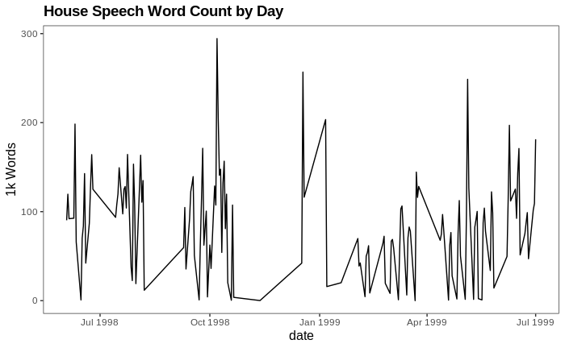

```r
dat_tt_words %>%
  group_by(date) %>%
  tally() %>%
  ggplot(aes(x = date, y = n/1000)) +
  geom_line() +
  theme_apa() +
  ggtitle('House Speech Word Count by Day') +
  ylab('1k Words')
```

We can also look at word frequencies by time and party:

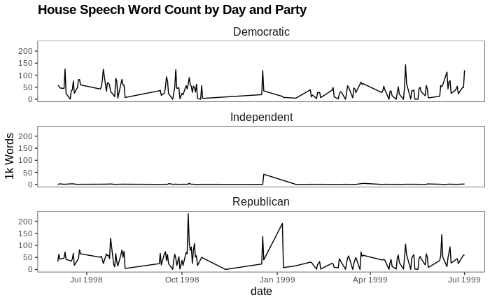

```r
dat_tt_words %>%
  group_by(date, Party) %>%
  tally() %>%
  ggplot(aes(x = date, y = n/1000)) +
  geom_line() +
  theme_apa() +
  ggtitle('House Speech Word Count by Day and Party') +
  ylab('1k Words') + facet_wrap(Party~., ncol=1)
```

#### Top words

We can (and you always should) also glance at the word distributions. E.g., what are the top words?

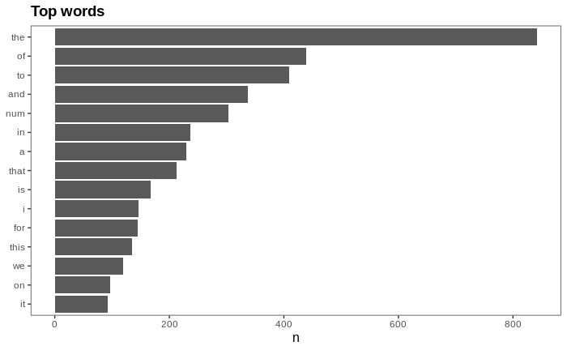

```r
dat_tt_words %>%
  count(word, sort = TRUE) %>%
  top_n(15, wt=n) %>%
  mutate(n = n/1000,
    word = reorder(word, n)) %>%
  ggplot(aes(word, n)) +
  geom_col() +
  xlab(NULL) +
  coord_flip() +
  theme_apa() +
  ggtitle('Top words')
```

Looking at the top words, it’s clear that the most frequent words are words like ‘the’, and ‘of’. Depending on the task at hand, you may or may not want to remove these kinds of words, which are referred to as *stop words*.

**Question:** When and why might you want to remove (or not remove) stop words?

We can easily remove stopwords using tidytext’s stop_words dataset and an anti-join:

```r
head(stop_words)
```

| word | lexicon |
| --- | --- |
| a | SMART |
| a's | SMART |
| able | SMART |
| about | SMART |
| above | SMART |
| according | SMART |

```r
dat_tt_words.cl <- dat_tt_words %>%
  anti_join(stop_words) %>%
  filter(word != 'num')
```

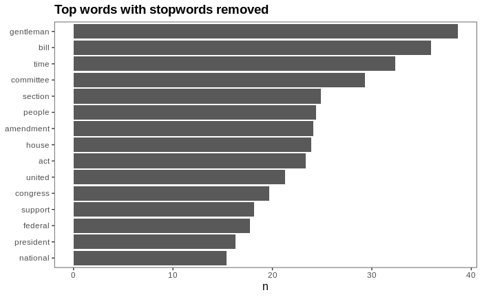

```r
dat_tt_words.cl %>%
  count(word, sort = TRUE) %>%
  top_n(15, wt=n) %>%
  mutate(n = n/1000,
    word = reorder(word, n)) %>%
  ggplot(aes(word, n)) +
  geom_col() +
  xlab(NULL) +
  coord_flip() +
  theme_apa() +
  ggtitle('Top words with stopwords removed')
```

```
Unequal factor levels: coercing to characterbinding character and factor vector, coercing into character vectorbinding character and factor vector, coercing into character vector
```

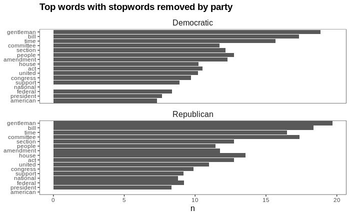

```r
dat_tt_words.cl %>%
  filter(Party != 'Independent') %>%
  group_by(Party) %>%
  count(word, sort = TRUE) %>%
  top_n(15, wt=n) %>%
  mutate(n = n/1000,
    word = reorder(word, n)) %>%
  ggplot(aes(reorder(word,n), n)) +
  geom_col(position=position_dodge()) +
  xlab(NULL) +
  coord_flip() +
  theme_apa() +
  ggtitle('Top words with stopwords removed by party') +
  facet_wrap(Party~., ncol=1)
```

```
Unequal factor levels: coercing to characterbinding character and factor vector, coercing into character vectorbinding character and factor vector, coercing into character vector
```

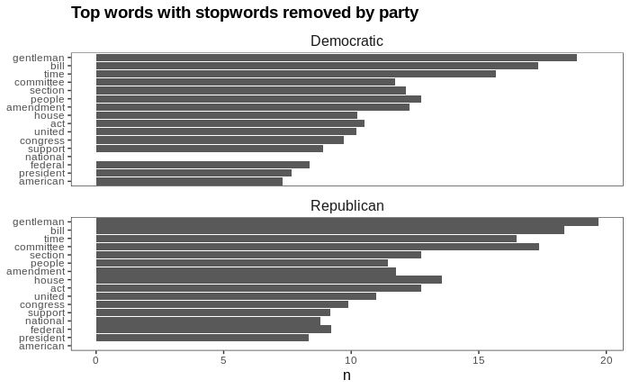

```r
dat_tt_words.cl %>%
  filter(Party != 'Independent') %>%
  group_by(Party) %>%
  count(word, sort = TRUE) %>%
  top_n(15, wt=n) %>%
  mutate(n = n/1000,
    word = reorder(word, n)) %>%
  ggplot(aes(reorder(word,n), n)) +
  geom_col(position=position_dodge()) +
  xlab(NULL) +
  coord_flip() +
  theme_apa() +
  ggtitle('Top words with stopwords removed by party') +
  facet_wrap(Party~., ncol=1)
```

```r
`%!in%` <- Negate(`%in%`)
dat_tt_words.cl <- dat_tt_words.cl %>%
  filter(word  %!in% c('gentleman', 'bill', 'time', 'committee', 'section', 'people', 'amendment', 'house', 'act', 'united', 'congress'))
```

```
Unequal factor levels: coercing to characterbinding character and factor vector, coercing into character vectorbinding character and factor vector, coercing into character vector
```

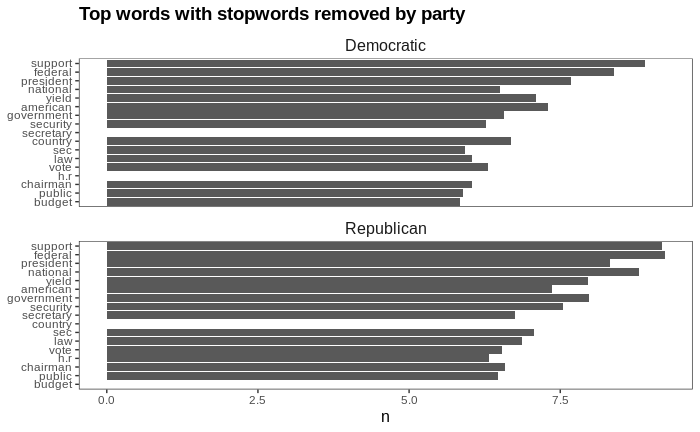

```r
dat_tt_words.cl %>%
  filter(Party != 'Independent') %>%
  group_by(Party) %>%
  count(word, sort = TRUE) %>%
  top_n(15, wt=n) %>%
  mutate(n = n/1000,
    word = reorder(word, n)) %>%
  ggplot(aes(reorder(word,n), n)) +
  geom_col(position=position_dodge()) +
  xlab(NULL) +
  coord_flip() +
  theme_apa() +
  ggtitle('Top words with stopwords removed by party') +
  facet_wrap(Party~., ncol=1)
```